# UNICEF-Sierra Leone COVID-19 Dashboard

Tracking health seeking behaviour, outcomes and government responses to COVID-19 in Sierra Leone

Continuous access to information on key economic indicators is essential to help Sierra Leone respond to the Covid-19 pandemic.dashboard provides real time data on current health trends from a phone based survey being rolled out in 195 towns and villages across Sierra Leone.[^1]

## Current cases

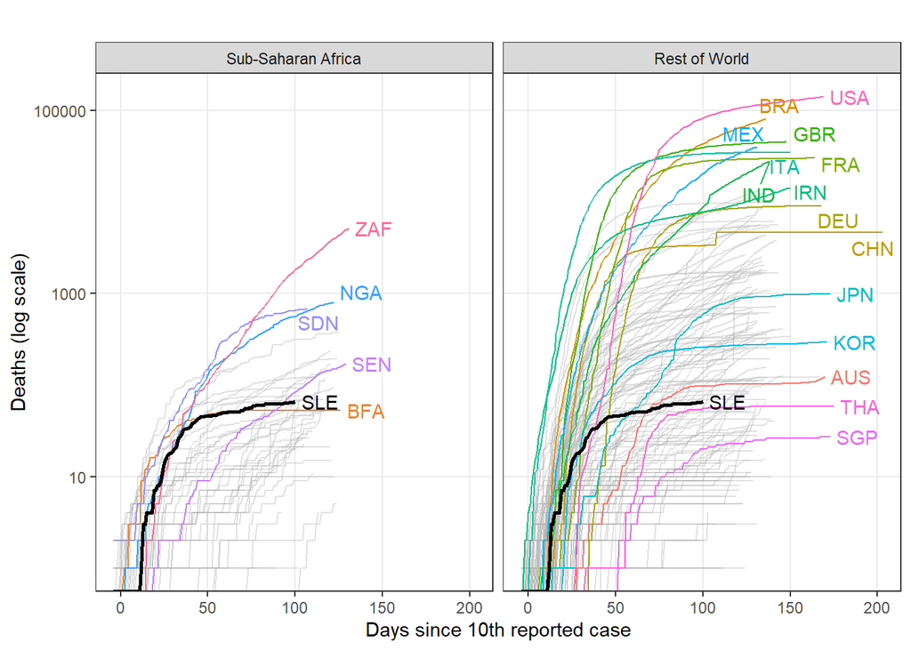

**Source**: Figures draw from the European Centre for Disease Prevention and Control

## Schooling

### Aggregates

#### Aggregates and time trends

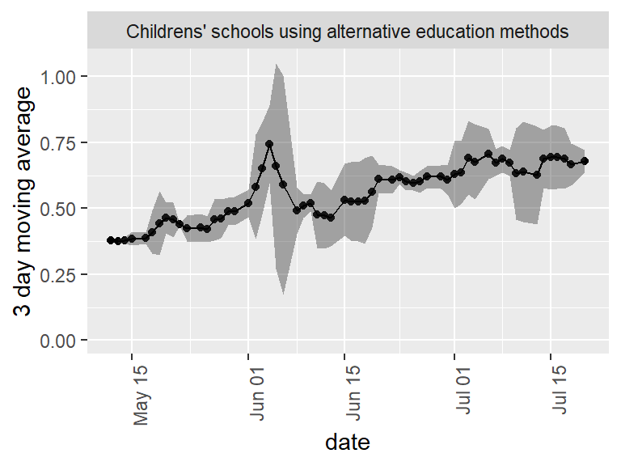

3 day moving average with 95% confidence intervals

### Current averages

Mean responses in each District (most recent date)

| District | Date | Childrens’ schools using alternative education methods |
| --- | --- | --- |
| Bo | 2020-07-20 | 0.35 |
| Bombali | 2020-07-20 | 0.27 |
| Bonthe | 2020-07-18 | 0.56 |
| Falaba | 2020-07-20 | 0.42 |
| Kailahun | 2020-07-20 | 0.60 |
| Kambia | 2020-07-20 | 0.49 |
| Karene | 2020-07-20 | 0.30 |
| Kenema | 2020-07-20 | 0.40 |
| Koinadugu | 2020-07-20 | 0.42 |
| Kono | 2020-07-20 | 0.48 |
| Moyamba | 2020-07-20 | 0.50 |
| Port Loko | 2020-07-20 | 0.35 |
| Pujehun | 2020-07-20 | 0.43 |
| Tonkolili | 2020-07-20 | 0.61 |
| NA | 2020-07-20 | 0.89 |

### Definitions of measures

Data definitions

| Measure | Definition | Range | Response options |
| --- | --- | --- | --- |
| Childrens’ schools using alternative education methods | Is your childs’ school using alternative methods to continue teaching during COVID19? | 0 - 1 | 1=Yes; 0=No |

## Social Distancing

### Aggregates

#### Aggregates and time trends

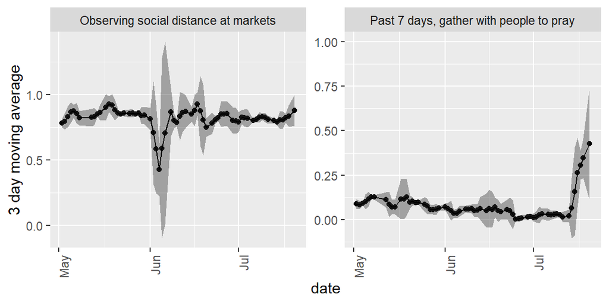

### Current averages

Mean responses in each District (most recent date)

| District | Date | Observing social distance at markets | Past 7 days, gather with people to pray |
| --- | --- | --- | --- |
| Bo | 2020-07-20 | 0.96 | 0.08 |
| Bombali | 2020-07-20 | 0.91 | 0.04 |
| Bonthe | 2020-07-18 | 0.95 | 0.02 |
| Falaba | 2020-07-20 | 0.95 | 0.05 |
| Kailahun | 2020-07-20 | 0.85 | 0.13 |
| Kambia | 2020-07-20 | 0.90 | 0.06 |
| Karene | 2020-07-20 | 0.91 | 0.05 |
| Kenema | 2020-07-20 | 0.99 | 0.07 |
| Koinadugu | 2020-07-20 | 0.94 | 0.04 |
| Kono | 2020-07-20 | 0.99 | 0.51 |
| Moyamba | 2020-07-20 | 0.95 | 0.11 |
| Port Loko | 2020-07-20 | 0.84 | 0.07 |
| Pujehun | 2020-07-20 | 0.98 | 0.11 |
| Tonkolili | 2020-07-20 | 0.98 | 0.03 |
| NA | 2020-07-20 | 0.35 | 0.02 |

### Definitions of measures

Data definitions

| Measure | Definition | Range | Response options |
| --- | --- | --- | --- |
| Observing social distance at markets | Are you keeping distance at the market? | 0 - 1 | 1=Yes; 0=No |
| Past 7 days, gather with people to pray | In the past 7 days, have you gathered with people to pray? | 0 - 1 | 1=Yes; 0=No |

## Prevention measures

### Aggregates

#### Aggregates and time trends

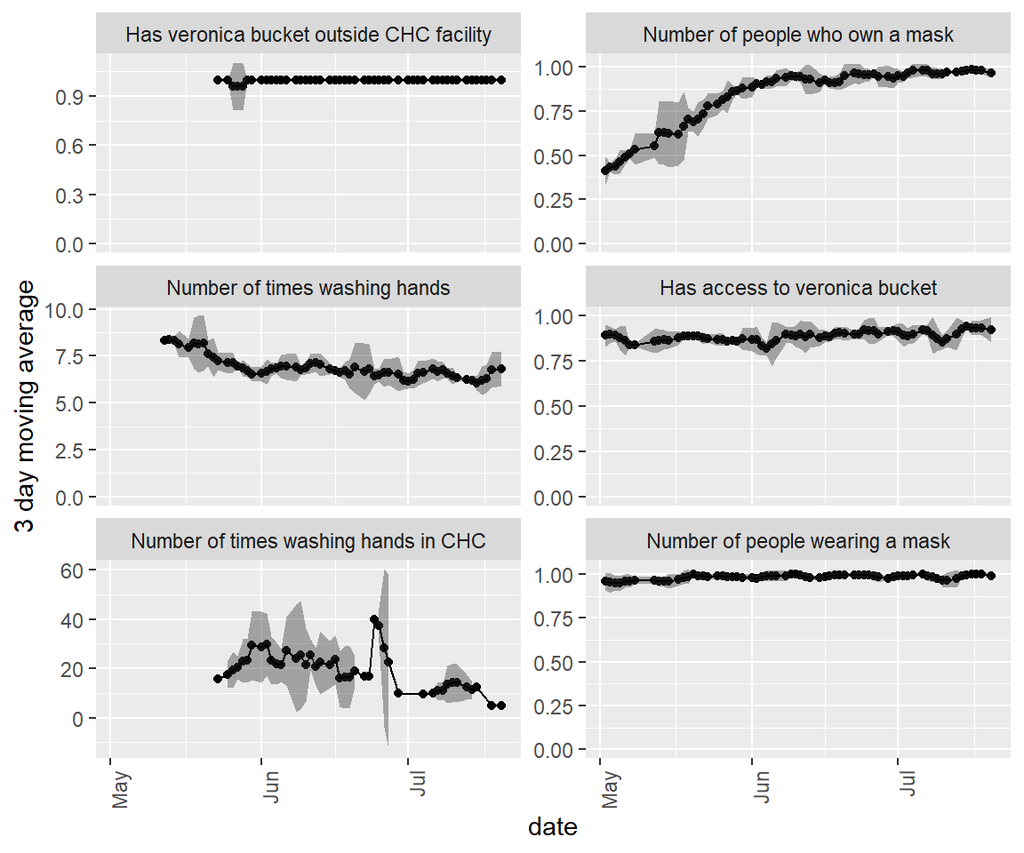

### Current averages

Mean responses in each District (most recent date)

| District | Date | Has access to veronica bucket | Has veronica bucket outside CHC facility | Number of people wearing a mask | Number of people who own a mask | Number of times washing hands | Number of times washing hands in CHC |
| --- | --- | --- | --- | --- | --- | --- | --- |
| Bo | 2020-07-20 | 0.94 | 1.00 | 0.98 | 0.82 | 6.85 | 19.67 |
| Bombali | 2020-07-20 | 0.92 | 1.00 | 0.96 | 0.62 | 6.46 | 16.25 |
| Bonthe | 2020-07-18 | 0.96 | 1.00 | 0.99 | 0.89 | 7.13 | 19.82 |
| Falaba | 2020-07-20 | 0.80 | 1.00 | 0.97 | 0.72 | 7.36 | 36.00 |
| Kailahun | 2020-07-20 | 0.87 | 1.00 | 0.99 | 0.83 | 9.71 | 26.00 |
| Kambia | 2020-07-20 | 0.90 | 1.00 | 0.99 | 0.76 | 5.50 | 24.44 |
| Karene | 2020-07-20 | 0.94 | 1.00 | 0.97 | 0.75 | 5.59 | 17.75 |
| Kenema | 2020-07-20 | 0.89 | 0.88 | 0.97 | 0.86 | 7.04 | 23.29 |
| Koinadugu | 2020-07-20 | 0.84 | 1.00 | 0.97 | 0.62 | 6.82 | 22.00 |
| Kono | 2020-07-20 | 0.78 | 1.00 | 0.96 | 0.82 | 7.25 | 12.22 |
| Moyamba | 2020-07-20 | 0.91 | 1.00 | 0.99 | 0.78 | 6.77 | 11.08 |
| Port Loko | 2020-07-20 | 0.93 | 1.00 | 0.99 | 0.80 | 7.44 | 26.08 |
| Pujehun | 2020-07-20 | 0.96 | 1.00 | 0.99 | 0.72 | 7.11 | 25.62 |
| Tonkolili | 2020-07-20 | 0.97 | 1.00 | 0.98 | 0.64 | 6.03 | 49.17 |
| NA | 2020-07-20 | 0.82 | NaN | 1.00 | 0.97 | 6.26 | NaN |

### Definitions of measures

Data definitions

| Measure | Definition | Range | Response options |
| --- | --- | --- | --- |
| Has access to veronica bucket | Number of people who have access to a veronica bucket | 0 - 1 | 1=Yes; 0=No |
| Has veronica bucket outside CHC facility | Do you have a veronica bucket outside your facility? | 0 - 1 | 1=Yes; 0=No |
| Number of people wearing a mask | Number of people who wear a mask outside | 0 - NA | Number of persons |
| Number of people who own a mask | Number of people who own a mask | 0 - NA | Number of persons |
| Number of times washing hands | How many times did you wash your hands yesterday? | 0 - NA | Number of times washing hands |
| Number of times washing hands in CHC | How many times in the day do you wash your hands when working at the CHC? | 0 - NA | Number of times washing hands at the CHC |

## Health seeking behaviour

### Aggregates

#### Aggregates and time trends

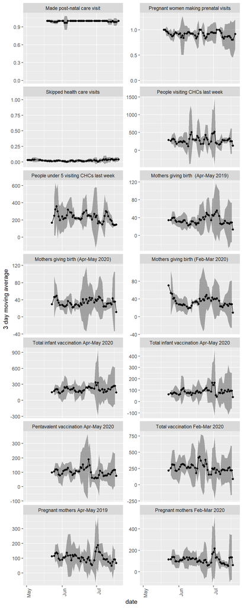

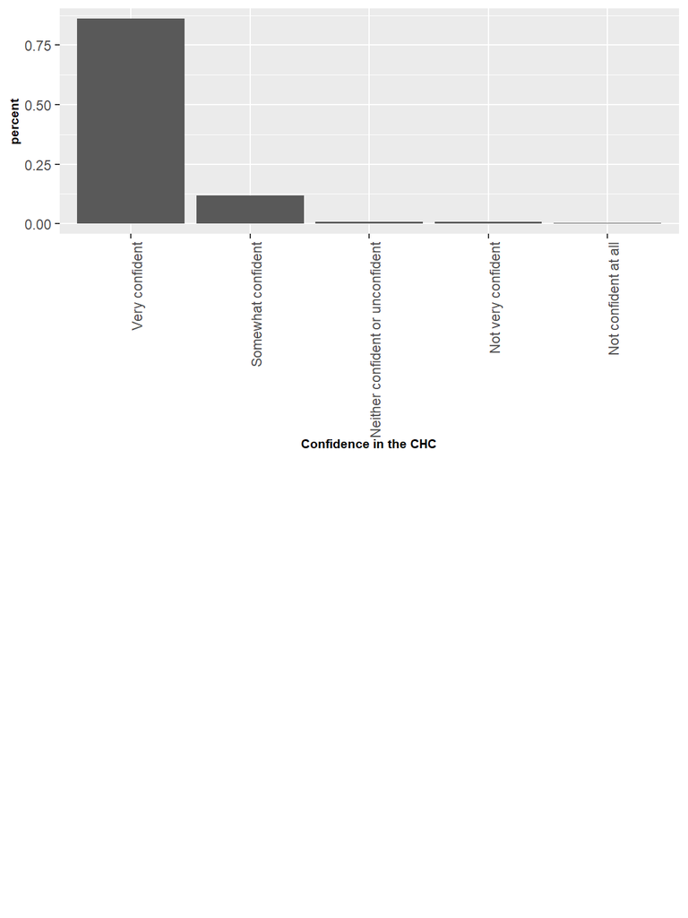

### Current averages

Mean responses in each District (most recent date)

| District | Date | Confidence in the CHC | Made post-natal care visit | Mothers giving birth (Apr-May 2019) | Mothers giving birth (Apr-May 2020) | Mothers giving birth (Feb-Mar 2020) | Pentavalent vaccination Apr-May 2020 | People under 5 visiting CHCs last week | People visiting CHCs last week | Pregnant mothers Apr-May 2019 | Pregnant mothers Feb-Mar 2020 | Pregnant women making prenatal visits | Skipped health care visits | Total infant vaccination Apr-May 2020 | Total infant vaccination Apr-May 2020 | Total vaccination Feb-Mar 2020 |
| --- | --- | --- | --- | --- | --- | --- | --- | --- | --- | --- | --- | --- | --- | --- | --- | --- |
| Bo | 2020-07-20 | 1.15 | 0.99 | 46.45 | 61.91 | 35.18 | 115.45 | 422.73 | 515.00 | 154.91 | 158.55 | 0.86 | 0.06 | 288.73 | 104.60 | 392.64 |
| Bombali | 2020-07-20 | 1.11 | 1.00 | 20.67 | 18.33 | 17.22 | 55.89 | 201.00 | 176.00 | 94.78 | 79.11 | 0.68 | 0.01 | 132.67 | 55.11 | 199.56 |
| Bonthe | 2020-07-18 | 1.17 | 1.00 | 22.58 | 21.58 | 22.83 | 73.75 | 321.91 | 289.83 | 89.25 | 94.25 | 0.94 | 0.03 | 130.67 | 57.08 | 194.08 |
| Falaba | 2020-07-20 | 1.13 | 1.00 | 30.09 | 23.18 | 28.91 | 101.82 | 132.55 | 201.18 | 105.09 | 142.00 | 1.00 | 0.01 | 160.55 | 78.64 | 251.09 |
| Kailahun | 2020-07-20 | 1.05 | 1.00 | 50.91 | 55.95 | 67.95 | 159.32 | 343.00 | 348.77 | 154.32 | 170.45 | 0.96 | 0.03 | 247.50 | 93.09 | 307.50 |
| Kambia | 2020-07-20 | 1.19 | 1.00 | 43.80 | 42.13 | 47.47 | 146.13 | 194.86 | 428.00 | 142.40 | 166.73 | 0.89 | 0.02 | 323.14 | 140.79 | 335.20 |
| Karene | 2020-07-20 | 1.10 | 0.96 | 32.50 | 23.75 | 33.75 | 104.75 | 231.75 | 194.25 | 158.50 | 139.25 | 0.78 | 0.02 | 85.25 | 32.50 | 386.25 |
| Kenema | 2020-07-20 | 1.21 | 1.00 | 36.67 | 36.78 | 37.44 | 98.44 | 259.78 | 327.89 | 134.00 | 133.22 | 0.94 | 0.03 | 216.56 | 96.56 | 431.11 |
| Koinadugu | 2020-07-20 | 1.08 | 1.00 | 28.00 | 27.64 | 22.91 | 95.40 | 242.55 | 203.00 | 110.18 | 104.45 | 0.97 | 0.02 | 142.27 | 58.36 | 238.73 |
| Kono | 2020-07-20 | 1.16 | 1.00 | 32.17 | 28.00 | 25.50 | 86.92 | 195.08 | 199.92 | 117.58 | 104.75 | 0.91 | 0.04 | 121.50 | 51.33 | 201.58 |
| Moyamba | 2020-07-20 | 1.12 | 1.00 | 27.84 | 25.24 | 23.32 | 83.76 | 176.20 | 173.84 | 88.52 | 72.88 | 0.92 | 0.01 | 149.60 | 68.76 | 220.36 |
| Port Loko | 2020-07-20 | 1.16 | 1.00 | 28.80 | 24.87 | 22.20 | 89.13 | 244.87 | 283.80 | 61.00 | 56.13 | 0.83 | 0.00 | 253.47 | 123.87 | 254.07 |
| Pujehun | 2020-07-20 | 1.15 | 1.00 | 28.44 | 29.78 | 25.78 | 119.78 | 346.56 | 259.44 | 120.33 | 122.00 | 1.00 | 0.05 | 215.00 | 83.56 | 272.44 |
| Tonkolili | 2020-07-20 | 1.85 | 0.99 | 19.00 | 15.43 | 16.43 | 114.00 | 278.57 | 283.57 | 52.86 | 51.71 | 0.95 | 0.00 | 255.57 | 103.71 | 313.71 |
| NA | 2020-07-20 | 1.12 | 0.99 | NaN | NaN | NaN | NaN | NaN | NaN | NaN | NaN | 0.92 | 0.02 | NaN | NaN | NaN |

### Definitions of measures

Data definitions

| Measure | Definition | Range | Response options |
| --- | --- | --- | --- |
| Confidence in the CHC | How confident you are that the community health clinic is able to help if you get sick? | NA - NA | 1=Very confident; 5= Not confident at all |
| Made post-natal care visit | Have you been making any post-natal care visits to a health clinic and getting vaccinations, and overall general health care for your baby? | 0 - 1 | 1=Yes; 0=No |
| Mothers giving birth (Apr-May 2019) | Total mothers that gave birth (Mother and Neonate) between April and May 2019 | 0 - NA | Number of mothers giving birth between April and May 2019 |
| Mothers giving birth (Apr-May 2020) | Total mothers that gave birth (Mother and Neonate) between April and May 2020 | 0 - NA | Number of mothers giving birth between April and May 2020 |
| Mothers giving birth (Feb-Mar 2020) | Total mothers that gave birth (Mother and Neonate) between February and March 2020 | 0 - NA | Number of mothers giving birth between February and March 2020 |
| Pentavalent vaccination Apr-May 2020 | Pentavalent Vaccinations (EPI Register) applied between April and May 2019 | 0 - NA | Number of pentavalent vaccination applied between April and May 2019 |
| People under 5 visiting CHCs last week | Number of children under 5 who visited CHCs in the past week | 0 - NA | Number of persons under 5 years-old visiting CHCs in the past week |
| People visiting CHCs last week | Number of people who have been recorded visiting CHCs in the past week | 0 - NA | Total number of people visiting CHCs in the last week |
| Pregnant mothers Apr-May 2019 | Pregnant women making visits to the CHC for Antenatal care (Mother and Neonate) between April and May 2019 | 0 - NA | Number of pregnant women making visits to the CHC for Antenatal care (Mother and Neonate) between April and May 2019 |
| Pregnant mothers Feb-Mar 2020 | Pregnant women making visits to the CHC for Antenatal care (Mother and Neonate) between February and March 2020 | 0 - NA | Number of pregnant mothers care (Mother and Neonate) |
| Pregnant women making prenatal visits | Are the pregnant women in your household making any antenatal care visits, vaccinations, and overall general health care to a health clinic for your baby? | 0 - 1 | 1=Yes; 0=No |
| Skipped health care visits | Have you delayed or skipped any needed health care visits? | 0 - 1 | 1=Yes; 0=No |
| Total infant vaccination Apr-May 2020 | April and May 2020- Total Infants (EPI Register) | 0 - NA | Number of total infant vaccination Total Infants (EPI Register) |
| Total infant vaccination Apr-May 2020 | April and May 2020- Male Infants (EPI Register) | 0 - NA | Number of total infant vaccination Male Infants (EPI Register) |
| Total vaccination Feb-Mar 2020 | February and March 2020- Total Vaccinations (EPI Register) | 0 - NA | Number of total vaccination Total Vaccinations (EPI Register) |

## Covid Symptoms

### Aggregates

#### Aggregates and time trends

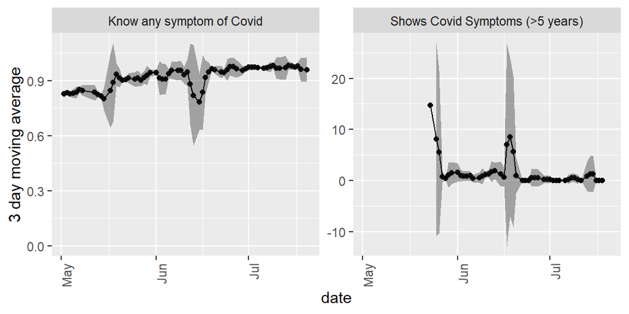

### Current averages

Mean responses in each District (most recent date)

| District | Date | Shows Covid Symptoms (>5 years) | Know any symptom of Covid |
| --- | --- | --- | --- |
| Bo | 2020-07-20 | 2.55 | 0.92 |
| Bombali | 2020-07-20 | 2.89 | 0.94 |
| Bonthe | 2020-07-18 | 3.08 | 0.89 |
| Falaba | 2020-07-20 | 1.18 | 0.86 |
| Kailahun | 2020-07-20 | 2.68 | 0.95 |
| Kambia | 2020-07-20 | 0.00 | 0.92 |
| Karene | 2020-07-20 | 2.25 | 0.89 |
| Kenema | 2020-07-20 | 12.22 | 0.93 |
| Koinadugu | 2020-07-20 | 1.09 | 0.87 |
| Kono | 2020-07-20 | 0.00 | 0.93 |
| Moyamba | 2020-07-20 | 0.00 | 0.92 |
| Port Loko | 2020-07-20 | 0.00 | 0.94 |
| Pujehun | 2020-07-20 | 0.00 | 0.87 |
| Tonkolili | 2020-07-20 | 0.00 | 0.86 |
| NA | 2020-07-20 | NaN | 0.88 |

### Definitions of measures

Data definitions

| Measure | Definition | Range | Response options |
| --- | --- | --- | --- |
| Shows Covid Symptoms (>5 years) | People above 5 years-old that presented Covid symptoms between April and May 2020 | 0 - NA | Number of persons with more than 5 y.o. that show Covid symptoms |
| Know any symptom of Covid | Number of respondents who know any symptoms of COVID-19 | 0 - NA | Number of persons |

## Aid reception

### Aggregates

#### Aggregates and time trends

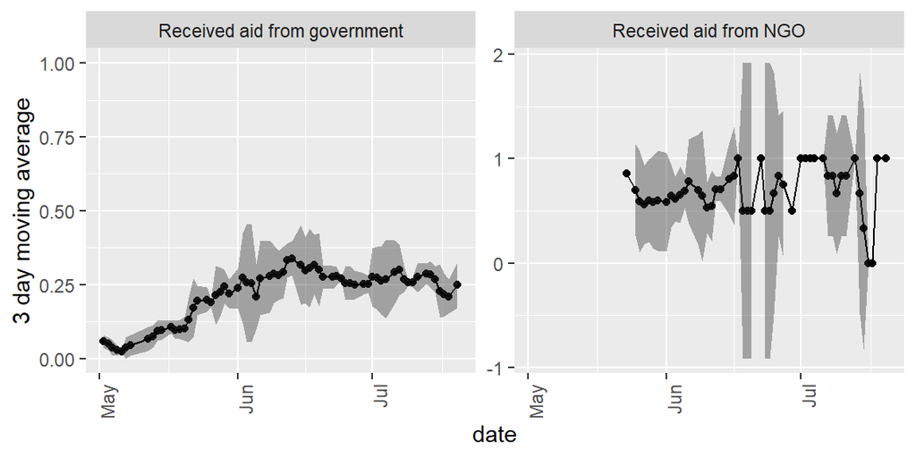

### Current averages

Mean responses in each District (most recent date)

| District | Date | Received aid from government | Received aid from NGO |
| --- | --- | --- | --- |
| Bo | 2020-07-20 | 0.14 | 0.67 |
| Bombali | 2020-07-20 | 0.08 | 0.50 |
| Bonthe | 2020-07-18 | 0.12 | 1.00 |
| Falaba | 2020-07-20 | 0.35 | 1.00 |
| Kailahun | 2020-07-20 | 0.24 | 0.37 |
| Kambia | 2020-07-20 | 0.25 | 0.89 |
| Karene | 2020-07-20 | 0.14 | 0.50 |
| Kenema | 2020-07-20 | 0.17 | 0.50 |
| Koinadugu | 2020-07-20 | 0.39 | 0.20 |
| Kono | 2020-07-20 | 0.38 | 1.00 |
| Moyamba | 2020-07-20 | 0.24 | 0.46 |
| Port Loko | 2020-07-20 | 0.22 | 0.77 |
| Pujehun | 2020-07-20 | 0.09 | 1.00 |
| Tonkolili | 2020-07-20 | 0.15 | 0.83 |
| NA | 2020-07-20 | 0.09 | NaN |

### Definitions of measures

Data definitions

| Measure | Definition | Range | Response options |
| --- | --- | --- | --- |
| Received aid from government | Has the government sent any aid/resources to your facility because of COVID-19? | 0 - 1 | 1=Yes; 0=No |
| Received aid from NGO | Has any NGO/foreign organization sent any aid/resources to your facility because | 0 - 1 | 1=Yes; 0=No |

## Access to Water

### Aggregates

#### Aggregates and time trends

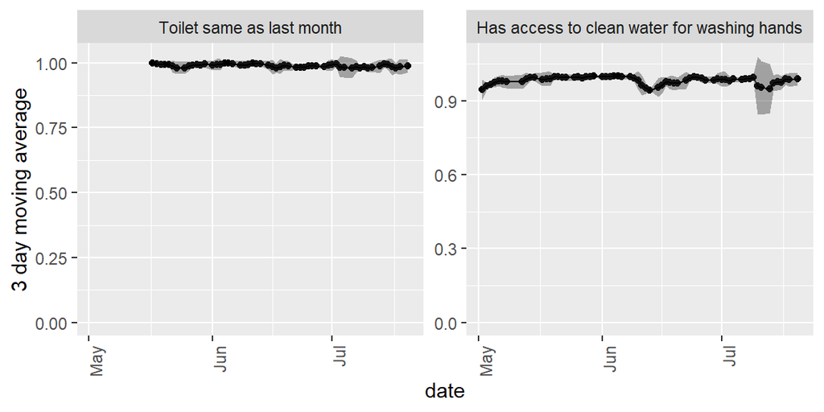

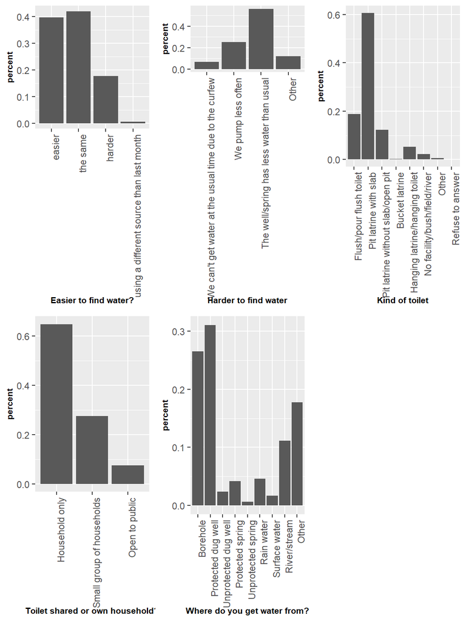

### Current averages

Mean responses in each District (most recent date)

| District | Date | Easier to find water? | Harder to find water | Has access to clean water for washing hands | Kind of toilet | Toilet same as last month | Toilet shared or own household? | Where do you get water from? |
| --- | --- | --- | --- | --- | --- | --- | --- | --- |
| Bo | 2020-07-20 | 1.43 | 11.47 | 1.00 | 2.53 | 0.96 | 1.90 | 2.88 |
| Bombali | 2020-07-20 | 1.30 | 27.40 | 1.00 | 2.57 | 1.00 | 1.36 | 27.31 |
| Bonthe | 2020-07-18 | 1.59 | 21.00 | 0.98 | 2.86 | 1.00 | 1.55 | 4.88 |
| Falaba | 2020-07-20 | 2.05 | 19.04 | 0.92 | 2.84 | 0.97 | 1.35 | 3.44 |
| Kailahun | 2020-07-20 | 2.25 | 2.26 | 0.98 | 3.09 | 0.99 | 1.59 | 39.24 |
| Kambia | 2020-07-20 | 2.03 | 5.02 | 0.99 | 1.93 | 0.99 | 1.27 | 4.93 |
| Karene | 2020-07-20 | 1.39 | 35.79 | 1.00 | 2.32 | 0.99 | 1.49 | 17.82 |
| Kenema | 2020-07-20 | 1.72 | 10.86 | 0.98 | 3.83 | 0.99 | 1.81 | 2.84 |
| Koinadugu | 2020-07-20 | 1.85 | 20.16 | 0.95 | 3.09 | 0.99 | 1.31 | 17.02 |
| Kono | 2020-07-20 | 1.90 | 15.00 | 0.94 | 4.32 | 0.98 | 1.42 | 16.48 |
| Moyamba | 2020-07-20 | 1.68 | 30.48 | 1.00 | 2.40 | 0.99 | 1.44 | 6.86 |
| Port Loko | 2020-07-20 | 1.48 | 6.57 | 0.98 | 2.42 | 1.00 | 1.15 | 5.44 |
| Pujehun | 2020-07-20 | 1.52 | 21.76 | 0.99 | 5.30 | 0.99 | 2.01 | 7.11 |
| Tonkolili | 2020-07-20 | 1.31 | 33.40 | 0.99 | 5.64 | 1.00 | 1.44 | 26.03 |
| NA | 2020-07-20 | 2.00 | 6.89 | 1.00 | 1.58 | 1.00 | 1.20 | 38.74 |

### Definitions of measures

Data definitions

| Measure | Definition | Range | Response options |
| --- | --- | --- | --- |
| Easier to find water? | Think back to LAST month, is it easier or harder to get water from this source? | NA - NA | 1=Easier; 2=The same; 3=Harder; 4=Changed from source of water |
| Harder to find water | Why is it harder? | NA - NA | Reasons it is harder to find water |
| Has access to clean water for washing hands | Number of people who have access to clean water to wash their hands | 0 - NA | Number of people with access to clean water |
| Kind of toilet | What kind of toilet facility does your household have? | NA - NA | Type of toilet |
| Toilet same as last month | Is this toilet facility the same as you used LAST month? | 0 - 1 | 1=Yes; 0=No |
| Toilet shared or own household? | Is this a shared toilet with only your household, among a small group of households, or open to the public? | NA - NA | Type of toilet |
| Where do you get water from? | In the past 7 days, where does your household get its water to wash from? | NA - NA | Source of water to wash |

## Access to information

### Aggregates

#### Aggregates and time trends

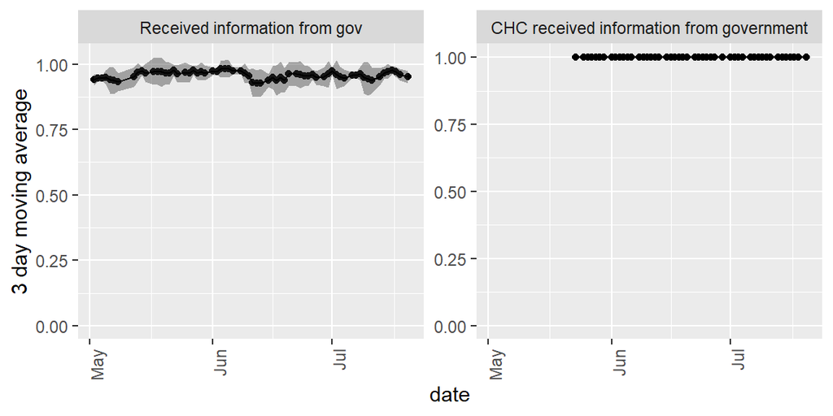

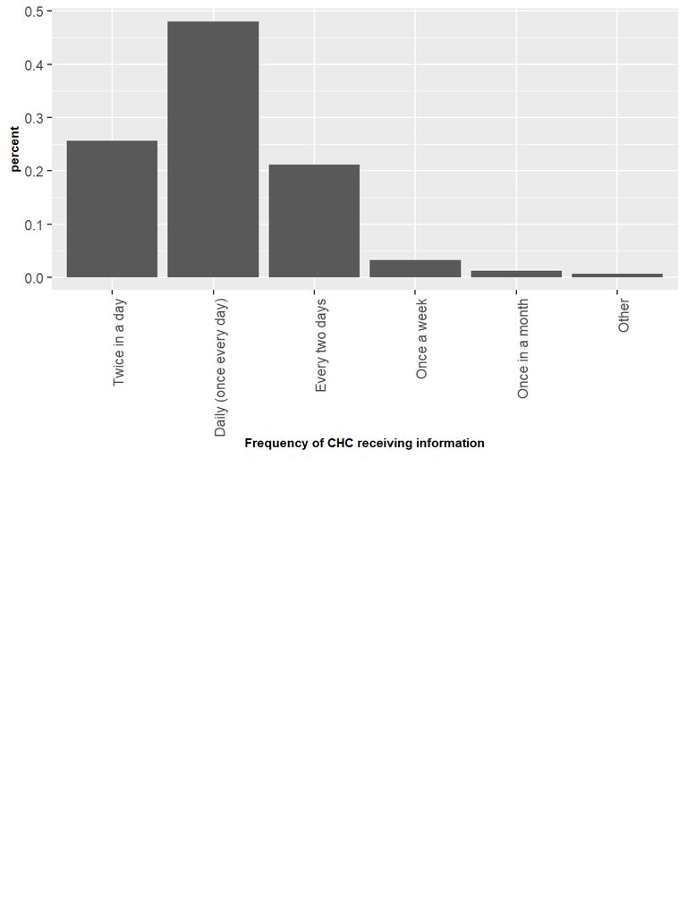

### Current averages

Mean responses in each District (most recent date)

| District | Date | CHC received information from government | Frequency of CHC receiving information | Received information from gov |
| --- | --- | --- | --- | --- |
| Bo | 2020-07-20 | 1 | 3.00 | 0.98 |
| Bombali | 2020-07-20 | 1 | 3.00 | 1.00 |
| Bonthe | 2020-07-18 | 1 | 3.09 | 0.98 |
| Falaba | 2020-07-20 | 1 | 1.00 | 0.76 |
| Kailahun | 2020-07-20 | 1 | 2.11 | 0.99 |
| Kambia | 2020-07-20 | 1 | 1.89 | 0.98 |
| Karene | 2020-07-20 | 1 | 2.75 | 1.00 |
| Kenema | 2020-07-20 | 1 | 1.00 | 0.97 |
| Koinadugu | 2020-07-20 | 1 | 1.00 | 0.86 |
| Kono | 2020-07-20 | 1 | 1.73 | 0.88 |
| Moyamba | 2020-07-20 | 1 | 2.71 | 0.98 |
| Port Loko | 2020-07-20 | 1 | 2.00 | 0.95 |
| Pujehun | 2020-07-20 | 1 | 2.00 | 0.97 |
| Tonkolili | 2020-07-20 | 1 | 2.00 | 0.98 |
| NA | 2020-07-20 | NaN | NaN | 0.99 |

### Definitions of measures

Data definitions

| Measure | Definition | Range | Response options |
| --- | --- | --- | --- |
| CHC received information from government | Number of CHCs receiving information about COVID-19 or coronavirus from the government | 0 - NA | Number of CHCs receiving info |
| Frequency of CHC receiving information | How frequently is the government sending information to your facility regarding | NA - NA | 1=Twice in a day; 2=Every day; 3=Every two days; 4=Once a week; 5=Once a month; 6=Never |
| Received information from gov | Are you receiving information from the government about COVID-19? | 0 - 1 | 1=Yes; 0=No |

## All Data

Data is representative for 195 semi-rural towns across all Districts of Sierra Leone, with an average of 492 households per town. Rural villages and District headquarter towns are excluded.

### Browse data

|  | id | date | district | alt_methods | dist_market | pray | veronica | chc_veronica | wear_mask | mask | num_hand | wash_num | chc_confident | per_gen_visits | tot_births_aprilmay19 | tot_births_aprilmay20 | tot_births_febmarch20 | tot_vac_aprilmay19 | tot_below5 | tot_above5 | tot_visits_aprilmay19 | tot_visits_febmarch20 | perc_natal_visits | skipped | tot_infantvac_aprilmay20 | tot_malevac_aprilmay20 | tot_vac_febmarch20 | tot_pat_sympt | gov_send | … |
| --- | --- | --- | --- | --- | --- | --- | --- | --- | --- | --- | --- | --- | --- | --- | --- | --- | --- | --- | --- | --- | --- | --- | --- | --- | --- | --- | --- | --- | --- | --- |
| 1 | Bo | 2020-04-30 | 31 |  | 0.889 | 0.222 | 1 |  | 1 | 0.556 |  |  | 1.111 |  |  |  |  |  |  |  |  |  |  | 0 |  |  |  |  | 0.111 | … |
| 2 | Bo | 2020-05-01 | 31 |  | 0.938 | 0.125 | 0.938 |  | 1 | 0.312 |  |  | 1.125 |  |  |  |  |  |  |  |  |  |  | 0 |  |  |  |  | 0.071 | … |
| 3 | Bo | 2020-05-02 | 31 |  | 0.812 | 0.188 | 0.812 |  | 0.875 | 0.5 |  |  | 1.125 |  |  |  |  |  |  |  |  |  |  | 0 |  |  |  |  | 0.077 | … |
| 4 | Bo | 2020-05-03 | 31 |  | 0.917 | 0.167 | 0.958 |  | 0.917 | 0.5 |  |  | 1.125 |  |  |  |  |  |  |  |  |  |  | 0.042 |  |  |  |  | 0.053 | … |
| 5 | Bo | 2020-05-04 | 31 |  | 1 | 0.182 | 0.864 |  | 0.923 | 0.591 |  |  | 1.095 |  |  |  |  |  |  |  |  |  |  | 0 |  |  |  |  | 0 | … |
| 6 | Bo | 2020-05-05 | 31 |  | 0.882 | 0.294 | 0.824 |  | 0.857 | 0.824 |  |  | 1.059 |  |  |  |  |  |  |  |  |  |  | 0.059 |  |  |  |  | 0 | … |
| 7 | Bo | 2020-05-06 | 31 |  | 1 | 0.333 | 0.933 |  | 1 | 0.6 |  |  | 1.067 |  |  |  |  |  |  |  |  |  |  | 0.2 |  |  |  |  | 0 | … |
| 8 | Bo | 2020-05-07 | 31 |  | 1 | 0.118 | 0.824 |  | 1 | 0.588 |  |  | 1.235 |  |  |  |  |  |  |  |  |  |  | 0 |  |  |  |  | 0 | … |
| 9 | Bo | 2020-05-08 | 31 |  | 1 | 0 | 0.75 |  | 1 | 0.75 |  |  | 1.5 |  |  |  |  |  |  |  |  |  |  | 0.25 |  |  |  |  | 0 | … |
| 10 | Bo | 2020-05-12 | 31 | 0.4 | 1 | 0.133 | 0.867 |  | 0.909 | 0.733 | 7.6 |  | 1 |  |  |  |  |  |  |  |  |  |  | 0.067 |  |  |  |  | 0 | … |

[output cut: 967 more lines]

### Data summaries

**Technical**: Summary measures on all data.

| variable | Bo | Bombali | Bonthe | Falaba | Kailahun | Kambia | Karene | Kenema | Koinadugu | Kono | Moyamba | Port Loko | Pujehun | Tonkolili | NA | Overall |
| --- | --- | --- | --- | --- | --- | --- | --- | --- | --- | --- | --- | --- | --- | --- | --- | --- |
| N | 625 | 346 | 491 | 567 | 1019 | 578 | 175 | 351 | 366 | 360 | 900 | 648 | 229 | 536 | 1436 | 8627 |
| district | 31 | 21 | 32 | 52 | 11 | 22 | 51 | 12 | 23 | 13 | 33 | 24 | 34 | 25 | 42 | 28.8335 |
| alt_methods | 0.3516 | 0.2705 | 0.558 | 0.416 | 0.604 | 0.4916 | 0.2958 | 0.4007 | 0.4225 | 0.4841 | 0.4984 | 0.3451 | 0.4343 | 0.6127 | 0.89 | 0.5438 |
| dist_market | 0.9608 | 0.905 | 0.9498 | 0.9459 | 0.8481 | 0.9037 | 0.9059 | 0.9912 | 0.9362 | 0.9885 | 0.9495 | 0.8421 | 0.9771 | 0.9849 | 0.3493 | 0.8337 |
| pray | 0.0768 | 0.0445 | 0.0188 | 0.0541 | 0.1268 | 0.0553 | 0.0529 | 0.0733 | 0.0435 | 0.5057 | 0.1068 | 0.0718 | 0.1055 | 0.0265 | 0.0187 | 0.0821 |
| veronica | 0.9379 | 0.9228 | 0.9582 | 0.8018 | 0.8692 | 0.902 | 0.9353 | 0.8856 | 0.8406 | 0.7787 | 0.9082 | 0.9314 | 0.9587 | 0.9716 | 0.8186 | 0.8858 |
| chc_veronica | 1 | 1 | 1 | 1 | 1 | 1 | 1 | 0.875 | 1 | 1 | 1 | 1 | 1 | 1 |  | 0.9936 |
| wear_mask | 0.978 | 0.9571 | 0.9906 | 0.9699 | 0.9878 | 0.9906 | 0.9685 | 0.9692 | 0.9721 | 0.9613 | 0.9897 | 0.994 | 0.9872 | 0.9765 | 0.9961 | 0.9843 |
| mask | 0.8154 | 0.6231 | 0.8891 | 0.7189 | 0.827 | 0.7611 | 0.7471 | 0.8563 | 0.6232 | 0.8161 | 0.7819 | 0.7959 | 0.7156 | 0.6446 | 0.9715 | 0.802 |
| num_hand | 6.8453 | 6.4613 | 7.1312 | 7.363 | 9.7087 | 5.5 | 5.5874 | 7.0389 | 6.8175 | 7.2549 | 6.771 | 7.4412 | 7.1099 | 6.0271 | 6.2574 | 6.943 |

[output cut: 30 more lines]

Notes

[^1]: This is made at UNICEF request. Data comes from a continous project by a team composed of Niccolo Meriggi (IGC Sierra Leone), Macartan Humphreys (WZB Berlin and Columbia Univerisity), Abou Bakarr Kamara (IGC Sierra Leone), Matthew Krupoff (Y-Rise), Madison Levine (Wageningen U), Mushfiq Mobarak (Yale University), Wilson Prichard (U Toronto), Ashwini Shridhar (Wageningen U), Julio Solís Arce (WZB Berlin), Peter van der Windt (NYU AD), Maarten Voors (Wageningen University). Feedback welcome! Please get in touch via email at tracking.corona.sl@gmail.com